# MAT442 - Project01

Titus S Ammerman

2025-02-09

> For centuries, people looked at the full moon with some trepidation. From stories of werewolves coming out, to more crime sprees, the full moon has gotten the blame. Some researchers (I will send you the article later this week) in the early 1970s set out to actually study whether there is a “fullmoon” effect on the mental health of people. The researchers collected admissions data for the emergency room at a mental health hospital for 12 months. They separated data into rates before the full moon (mean number of patients seen 4 to 13 days before the full moon), during the full moon (the number of patients seen on the full moon day), and after the full moon (mean number of patients seen 4 to 13 days after the full moon). They also kept track of which month the data came from since there was likely to be a relationship between admissions and the season of the year. The data can be found on D2L in the file MentalHealth.csv (also attached in the D2L Submission folder). Analyze the data to answer the researchers’ question.

# Abstract

## Purpose

Questions to be addressed?

- Are hospital admissions associated with lunar phase?
- Are hospital admissions independent to lunar phase given seasonal differences?
  - Does the relationship between lunar phase and hospital admissions depend on the season?

## Background

# Exploratory Data Analysis

```
## # A tibble: 36 × 3
##    Month Moon   Admission
##    <fct> <fct>      <dbl>
##  1 Aug   Before       6.4
##  2 Sep   Before       7.1
##  3 Oct   Before       6.5
##  4 Nov   Before       8.6
##  5 Dec   Before       8.1
##  6 Jan   Before      10.4
##  7 Feb   Before      11.5
##  8 Mar   Before      13.8
##  9 Apr   Before      15.4
## 10 May   Before      15.7
## # ℹ 26 more rows
```

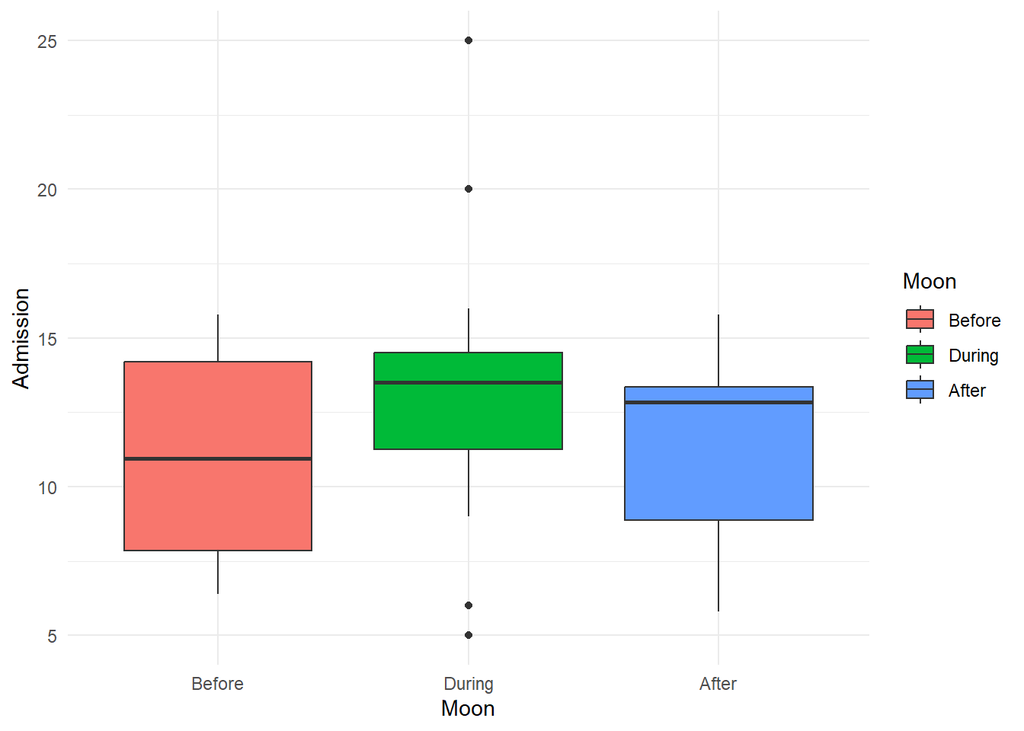

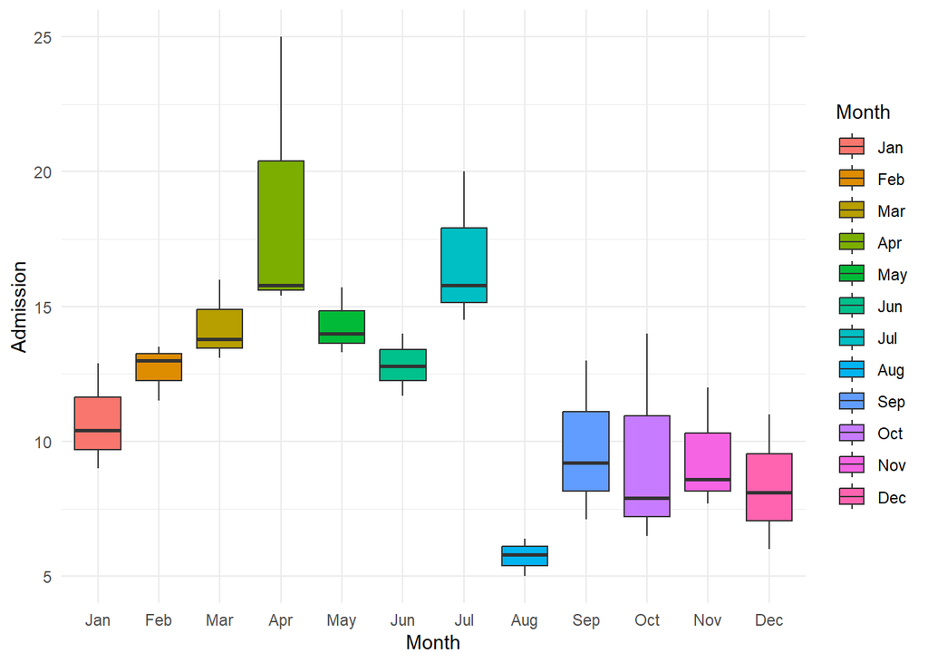

We will crease a `season` variable to observe trends that may be less apparent when viewing admissions on a monthly basis:

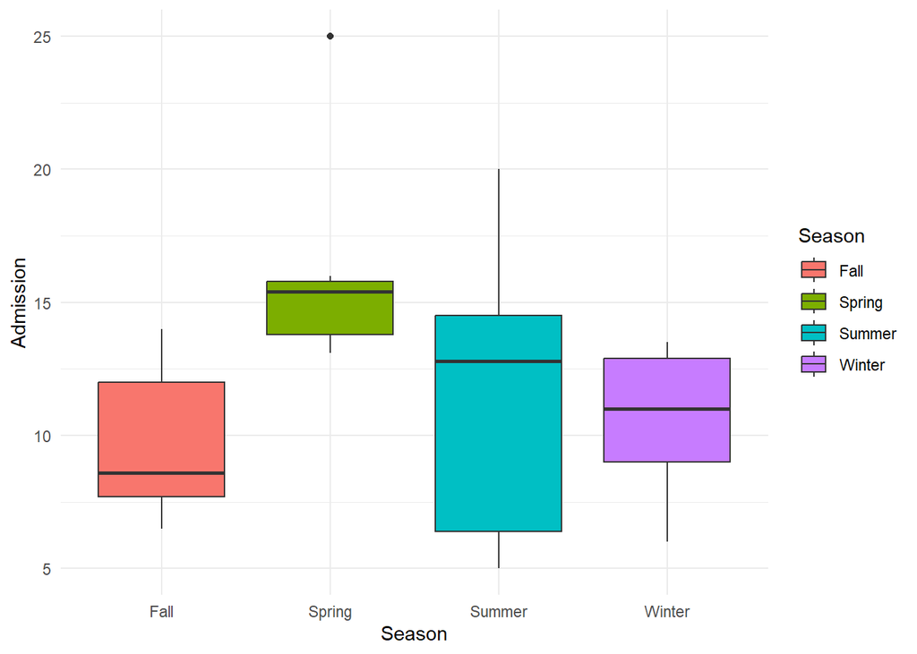

```
##         Moon
## Season   Before During After
##   Fall     22.2   39.0  24.8
##   Spring   44.9   55.0  42.2
##   Summer   33.9   39.0  33.1
##   Winter   30.0   28.0  37.4
```

## Testing the Normality of the Distributions

We will start by observing the distribution of the seasons:

```
## # A tibble: 4 × 2
##   Season `Observation Count`
##   <chr>                <int>
## 1 Fall                     9
## 2 Spring                   9
## 3 Summer                   9
## 4 Winter                   9
```

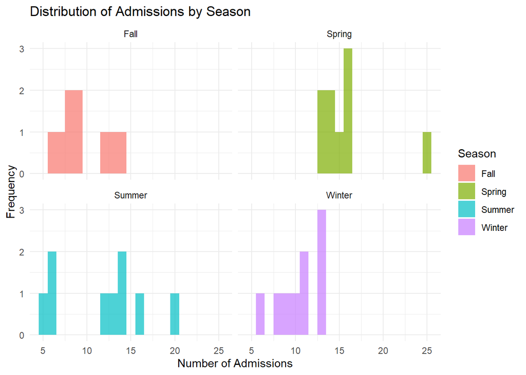

# Model Selection

```
##             Df Sum Sq Mean Sq F value  Pr(>F)
## Moon         2  41.51   20.76   1.577 0.22735
## Season       3 200.89   66.96   5.086 0.00724 **
## Moon:Season  6  66.53   11.09   0.842 0.55002
## Residuals   24 315.99   13.17
## ---
## Signif. codes:  0 '***' 0.001 '**' 0.01 '*' 0.05 '.' 0.1 ' ' 1
```

```
##             Df Sum Sq Mean Sq F value  Pr(>F)
## Moon         2   41.5   20.76   1.628 0.21320
## Season       3  200.9   66.96   5.252 0.00494 **
## Residuals   30  382.5   12.75
## ---
## Signif. codes:  0 '***' 0.001 '**' 0.01 '*' 0.05 '.' 0.1 ' ' 1
```

According to the ANOVA table, the Season seems to have the greatest effect on admissions.

```
##
##  Shapiro-Wilk normality test
##
## data:  residuals(anova_model)
## W = 0.95438, p-value = 0.1436
```

```
## Levene's Test for Homogeneity of Variance (center = median)
##       Df F value Pr(>F)
## group 11  1.0764 0.4185
##       24
```

The assumption of the normality of the residuals is met through the Shapiro-Wilk test. The homogeneity assumption of the variance is met through the Levene test.

```
##   Tukey multiple comparisons of means
##     95% family-wise confidence level
##
## Fit: aov(formula = Admission ~ Moon * Season, data = MentalHealth)
##
## $Moon
##                     diff       lwr      upr     p adj
## During-Before  2.5000000 -1.199318 6.199318 0.2303834
## After-Before   0.5416667 -3.157651 4.240984 0.9291646
## After-During  -1.9583333 -5.657651 1.740984 0.3970873
##
## $Season
##                    diff       lwr        upr     p adj
## Spring-Fall    6.233333  1.514739 10.9519274 0.0065914
## Summer-Fall    2.222222 -2.496372  6.9408163 0.5723088
## Winter-Fall    1.044444 -3.674150  5.7630385 0.9277072
## Summer-Spring -4.011111 -8.729705  0.7074829 0.1157989
## Winter-Spring -5.188889 -9.907483 -0.4702948 0.0273852
## Winter-Summer -1.177778 -5.896372  3.5408163 0.9004473
##
## $`Moon:Season`
##                                      diff         lwr       upr     p adj
## During:Fall-Before:Fall      5.600000e+00  -5.0822859 16.282286 0.7540075
## After:Fall-Before:Fall       8.666667e-01  -9.8156192 11.548953 1.0000000
## Before:Spring-Before:Fall    7.566667e+00  -3.1156192 18.248953 0.3558309
## During:Spring-Before:Fall    1.093333e+01   0.2510474 21.615619 0.0416026
## After:Spring-Before:Fall     6.666667e+00  -4.0156192 17.348953 0.5329890
## Before:Summer-Before:Fall    3.900000e+00  -6.7822859 14.582286 0.9685406
## During:Summer-Before:Fall    5.600000e+00  -5.0822859 16.282286 0.7540075
## After:Summer-Before:Fall     3.633333e+00  -7.0489526 14.315619 0.9810148
## Before:Winter-Before:Fall    2.600000e+00  -8.0822859 13.282286 0.9987694
## During:Winter-Before:Fall    1.933333e+00  -8.7489526 12.615619 0.9999233
## After:Winter-Before:Fall     5.066667e+00  -5.6156192 15.748953 0.8468816
## After:Fall-During:Fall      -4.733333e+00 -15.4156192  5.948953 0.8937456
## Before:Spring-During:Fall    1.966667e+00  -8.7156192 12.648953 0.9999094
## During:Spring-During:Fall    5.333333e+00  -5.3489526 16.015619 0.8028935
## After:Spring-During:Fall     1.066667e+00  -9.6156192 11.748953 0.9999998
## Before:Summer-During:Fall   -1.700000e+00 -12.3822859  8.982286 0.9999786
## During:Summer-During:Fall   -1.776357e-15 -10.6822859 10.682286 1.0000000
## After:Summer-During:Fall    -1.966667e+00 -12.6489526  8.715619 0.9999094
```

[output cut: 33 more lines]

```
## During:Summer-Before:Summer  1.700000e+00  -8.9822859 12.382286 0.9999786
## After:Summer-Before:Summer  -2.666667e-01 -10.9489526 10.415619 1.0000000
## Before:Winter-Before:Summer -1.300000e+00 -11.9822859  9.382286 0.9999986
## During:Winter-Before:Summer -1.966667e+00 -12.6489526  8.715619 0.9999094
## After:Winter-Before:Summer   1.166667e+00  -9.5156192 11.848953 0.9999996
## After:Summer-During:Summer  -1.966667e+00 -12.6489526  8.715619 0.9999094
## Before:Winter-During:Summer -3.000000e+00 -13.6822859  7.682286 0.9957760
## During:Winter-During:Summer -3.666667e+00 -14.3489526  7.015619 0.9797038
## After:Winter-During:Summer  -5.333333e-01 -11.2156192 10.148953 1.0000000
## Before:Winter-After:Summer  -1.033333e+00 -11.7156192  9.648953 0.9999999
## During:Winter-After:Summer  -1.700000e+00 -12.3822859  8.982286 0.9999786
## After:Winter-After:Summer    1.433333e+00  -9.2489526 12.115619 0.9999962
## During:Winter-Before:Winter -6.666667e-01 -11.3489526 10.015619 1.0000000
## After:Winter-Before:Winter   2.466667e+00  -8.2156192 13.148953 0.9992335
## After:Winter-During:Winter   3.133333e+00  -7.5489526 13.815619 0.9939621
```

Notable results: -Spring-Fall ($p = 0.0065914$) -Winter-Spring ($p = 0.0273852$)

```
##
##  Two Sample t-test
##
## data:  Admission by Moon
## t = -1.3151, df = 22, p-value = 0.202
## alternative hypothesis: true difference in means between group Before and group During is not equal to 0
## 95 percent confidence interval:
##  -6.442563  1.442563
## sample estimates:
## mean in group Before mean in group During
##             10.91667             13.41667
```

```
##
##  Two Sample t-test
##
## data:  Admission by Season
## t = -4.1075, df = 16, p-value = 0.0008235
## alternative hypothesis: true difference in means between group Fall and group Spring is not equal to 0
## 95 percent confidence interval:
##  -9.450378 -3.016289
## sample estimates:
##   mean in group Fall mean in group Spring
##             9.555556            15.788889
```

# Conclusion

We found that `season` was the most significant predictor of hospital admissions, with lunar phase failing to meet our significance threshold. More specifically, there seems to be a significant increase in admissions between the Fall and Spring months.

## Limitations

The study is limited by the relatively low sample size when considering the segmentation of the data that took place when placing it into a contingency table. A future study may aggregate data from multiple hospital locations, perhaps with varying climates, to see if the association with season and Admissions is spurious and simply a consequence of temperatures restraining activities and thus the potential for injury.